# Self-Driving Car Engineer Nanodegree

## Project: Build a Traffic Sign Recognition Classifier

In this notebook, a template is provided for you to implement your functionality in stages, which is required to successfully complete this project. If additional code is required that cannot be included in the notebook, be sure that the Python code is successfully imported and included in your submission if necessary.

In addition to implementing code, there is a writeup to complete. The writeup should be completed in a separate file, which can be either a markdown file or a pdf document. There is a [write up template](https://github.com/udacity/CarND-Traffic-Sign-Classifier-Project/blob/master/writeup_template.md) that can be used to guide the writing process. Completing the code template and writeup template will cover all of the [rubric points](https://review.udacity.com/#!/rubrics/481/view) for this project.

The [rubric](https://review.udacity.com/#!/rubrics/481/view) contains "Stand Out Suggestions" for enhancing the project beyond the minimum requirements. The stand out suggestions are optional. If you decide to pursue the "stand out suggestions", you can include the code in this Ipython notebook and also discuss the results in the writeup file.

> **Note:** Code and Markdown cells can be executed using the **Shift + Enter** keyboard shortcut. In addition, Markdown cells can be edited by typically double-clicking the cell to enter edit mode.

## Step 0: Load The Data

```python
import requests, zipfile, io, pickle
import matplotlib.pyplot as plt
import matplotlib.image as mpimg
import matplotlib
import random
import numpy as np
import csv
import cv2
from sklearn.utils import shuffle
import cv2
import tensorflow as tf
import math
import os
from tensorflow.contrib.layers import flatten

import xlsxwriter as xlw
Xlcount=0
%matplotlib inline
```

xlwt syntax

sh1.write(0, 0, 1234.56)

book.save('test.xls')

```python
#create definition for Xcl sheet
if(os.path.isfile('SimulationNumber.pckl')):
    f1 = open('SimulationNumber.pckl', 'rb')
    [Xlcount] = pickle.load(f1)
    f1.close()


#Initiate book
book = xlw.Workbook('Simulation '+str(Xlcount)+'.xlsx')

#style formats
bold = book.add_format({'bold': True})
italic = book.add_format({'italic': True})
red = book.add_format({'color': 'red'})
blue = book.add_format({'color': 'blue'})

#Initate Sheets
ParameterSheet = book.add_worksheet("Parameters")
LabelSheet = book.add_worksheet("Labels")
NNSheet = book.add_worksheet("NN_Architecture")

Xlcount+=1
f3 = open('SimulationNumber.pckl', 'wb')
pickle.dump([Xlcount], f3)
f3.close()
```

## Initial Code to download files

```python
f1 = open('InitialData.pckl', 'rb')
[train,test,X,Y,X_test,y_test] = pickle.load(f1)
f1.close()
```

## Step 1: Dataset Summary & Exploration

The pickled data is a dictionary with 4 key/value pairs:

- `'features'` is a 4D array containing raw pixel data of the traffic sign images, (num examples, width, height, channels).
- `'labels'` is a 1D array containing the label/class id of the traffic sign. The file `signnames.csv` contains id -> name mappings for each id.
- `'sizes'` is a list containing tuples, (width, height) representing the original width and height the image.
- `'coords'` is a list containing tuples, (x1, y1, x2, y2) representing coordinates of a bounding box around the sign in the image. **THESE COORDINATES ASSUME THE ORIGINAL IMAGE. THE PICKLED DATA CONTAINS RESIZED VERSIONS (32 by 32) OF THESE IMAGES**

Complete the basic data summary below. Use python, numpy and/or pandas methods to calculate the data summary rather than hard coding the results. For example, the [pandas shape method](http://pandas.pydata.org/pandas-docs/stable/generated/pandas.DataFrame.shape.html) might be useful for calculating some of the summary results.

### Provide a Basic Summary of the Data Set Using Python, Numpy and/or Pandas

```python
### Replace each question mark with the appropriate value.
### Use python, pandas or numpy methods rather than hard coding the results

# TODO: Number of training examples
n_train = len(X)

# TODO: Number of testing examples.
n_test = len(X_test)

# TODO: What's the shape of an traffic sign image?
image_shape = X.shape[1:4]

# TODO: How many unique classes/labels there are in the dataset.
n_classes = len(set(Y))

print("Presplit Length" , len(X))
print("Number of training examples =", n_train)
print("Number of testing examples =", n_test)
print("Image data shape =", image_shape)
print("Number of classes =", n_classes)\

cell_format = book.add_format({'align': 'center',
                                   'valign': 'vcenter',
                                   'border': 1})
ParameterSheet.merge_range('A1:B1', "", cell_format)
#Main Heading
ParameterSheet.write_rich_string('A1',bold,'Initial DataSet')
#Labels
ParameterSheet.write_rich_string('A2',italic,'No. Of Training Samples')
ParameterSheet.write_rich_string('A3',italic,'No. Of Testing Samples')
ParameterSheet.write_rich_string('A4',italic,'Shape of Image')
ParameterSheet.write_rich_string('A5',italic,'No. of classes')
#data
ParameterSheet.write('B2',n_train)
ParameterSheet.write('B3',n_test)
ParameterSheet.write('B4',str(image_shape))
ParameterSheet.write('B5',n_classes)
```

```
Presplit Length 34799
Number of training examples = 34799
Number of testing examples = 12630
Image data shape = (32, 32, 3)
Number of classes = 43
```

```
0
```

### Include an exploratory visualization of the dataset

Visualize the German Traffic Signs Dataset using the pickled file(s). This is open ended, suggestions include: plotting traffic sign images, plotting the count of each sign, etc.

The [Matplotlib](http://matplotlib.org/) [examples](http://matplotlib.org/examples/index.html) and [gallery](http://matplotlib.org/gallery.html) pages are a great resource for doing visualizations in Python.

**NOTE:** It's recommended you start with something simple first. If you wish to do more, come back to it after you've completed the rest of the sections. It can be interesting to look at the distribution of classes in the training, validation and test set. Is the distribution the same? Are there more examples of some classes than others?

```python
### Data exploration visualization code goes here.
### Feel free to use as many code cells as needed.

# Visualizations will be shown in the notebook.
%matplotlib inline

classid  =[]
Sign =[]
with open('signnames.csv') as csvfile:
    reader = csv.DictReader(csvfile)
    for row in reader:
        classid.append(row['ClassId'])
        Sign.append(row['SignName'])
print("Done")
```

```
Done
```

```python
print("Value assignment","           ",'Labels')
for i in range (n_classes):
    print("       ", i,"            " ,Sign[i])
    LabelSheet.write('A'+str(i+1),i)
    LabelSheet.write('B'+str(i+1),Sign[i])
```

```
Value assignment             Labels
        0              Speed limit (20km/h)
        1              Speed limit (30km/h)
        2              Speed limit (50km/h)
        3              Speed limit (60km/h)
        4              Speed limit (70km/h)
        5              Speed limit (80km/h)
        6              End of speed limit (80km/h)
        7              Speed limit (100km/h)
        8              Speed limit (120km/h)
        9              No passing
        10              No passing for vehicles over 3.5 metric tons
        11              Right-of-way at the next intersection
        12              Priority road
        13              Yield
```

[output cut: 29 more lines]

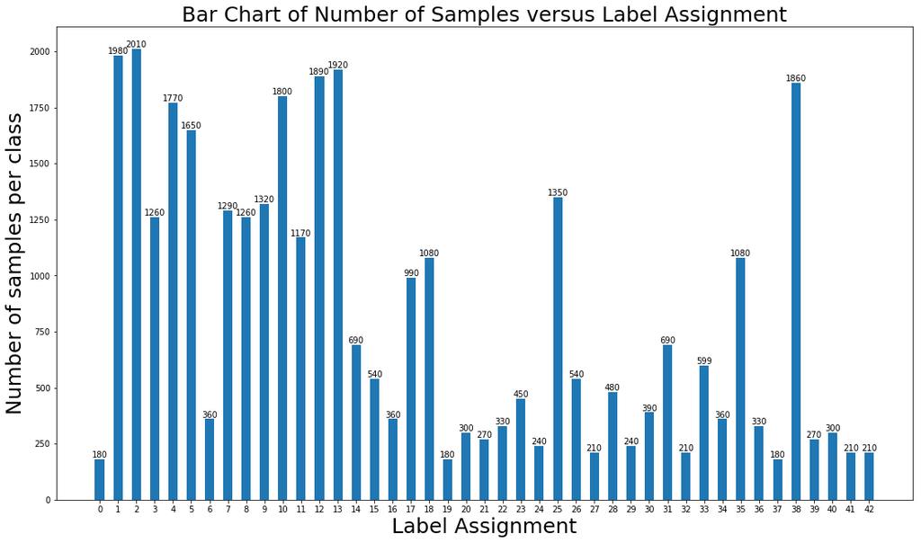

```python
Classes=np.zeros(n_classes)
for i in range(len(Y)):
    Classes[Y[i]] += 1

ind = np.arange(n_classes)
width=0.5

fig, ax = plt.subplots()
fig.set_size_inches(18.5, 10.5)
p=ax.bar(ind,Classes, width)
ax.set_xticks(range(n_classes))
ax.set_ylabel('Number of samples per class',fontsize=25)
ax.set_xlabel('Label Assignment',fontsize=25)
ax.set_title('Bar Chart of Number of Samples versus Label Assignment',fontsize=25)
for rect in p:
    height = rect.get_height()
    ax.text(rect.get_x() +rect.get_width()/2. , height,'%d' %int(height),ha='center',va='bottom')

fig.savefig('tempImages\image1.png')

ParameterSheet.merge_range('E1:L1', "", cell_format)

ParameterSheet.write_rich_string('E1',bold,'Bar Chart of Number of Samples versus Label Assignment')
ParameterSheet.insert_image('E2', 'tempImages\image1.png',{'x_scale': 0.3, 'y_scale': 0.3})
```